# R tutorial of scBiG

In this tutorial, we go over how to use basic scBiG functionality in R. If users have done preprocessing with `Seurat` and would like to continue to use scBiG, they can refer to this tutorial. It requires `reticulate` and `sceasy`, please install `reticulate`, `sceasy` and `scbig` first. However, for more involved analyses, we suggest using scBiG from Python.

## Load required packages

```r
library(Seurat)
library(dplyr)
library(patchwork)
library(R.utils)
library(rhdf5)
library(hdf5r)
library(sceasy)
library(Matrix)
library(igraph)
library(reticulate)
library(anndata)
```

## Specify Python environment

Here is the virtual environment used during scBig testing. Users can modify it according to actual conditions.

```r
use_condaenv("base")
```

## Load data

This data could be downloaded from https://drive.google.com/drive/folders/1JX589QWH7N895cAMAdJR9KDaFEigy1r3.

Here is the example dataset (`h5` file) where `X` is the count matrix and `Y` is the cell type label. Notably, scBiG is an unsupervised architecture and the cell type label is solely used for visualization and calculation of clustering metrics.

You can specify the path of your data here:

```r
name  <- "Human_pancreatic_islets"
dataPath <- paste0("./", name, ".h5")
raw_count <- h5read(dataPath, "X")
celltype <- h5read(dataPath, "Y")
celltype <- as.character(celltype)
colnames <- colnames(raw_count, do.NULL = FALSE)
rownames <- rownames(raw_count, do.NULL = FALSE)
colnames(raw_count) <- colnames
rownames(raw_count) <- rownames
real.data <- raw_count
```

## Create Seurat objects and data pre-processing

```r
options(Seurat.object.assay.version = "v3")
data <- CreateSeuratObject(counts = real.data,min.cells = 3, min.features = 200)
data <- NormalizeData(data, normalization.method = "LogNormalize", scale.factor = 10000)
# Calculate cs_factor
data@meta.data$cs_factor <- data@meta.data$nCount_RNA / median(data@meta.data$nCount_RNA)
data@meta.data$celltype <- celltype
# Calculate gs_factor
data[["RNA"]]@meta.features$gs_factor <- apply(data[["RNA"]]$data, 1, max)

# Select high variable genes (Optional)
data <- FindVariableFeatures(data, verbose = FALSE)
top2000 <- head(VariableFeatures(data), 2000)
data <- data[top2000]
```

## Convert Seurat objects into AnnData objects

```r
adata <- convertFormat(data, from="seurat", to="anndata", main_layer="counts", drop_single_values=FALSE)
adata$X = adata$X$todense()
adata$raw = adata
```

## Train scBiG

In default mode, the function `run_scbig` takes a preprocessed AnnData object as input. The output returns the updated AnnData object with cell embeddings stored in `adata.obsm['feat']` and louvain clustering results stored in `adata.obs['louvain']`.

In addition, function `run_scbig` would print and return all results during each logging training:

- all_loss: loss of training
- ari_k: ARI of KMeans
- ari_l: ARI of Louvain
- nmi_k: NMI of KMeans
- nmi_l: NMI of Louvain

```r
scbig <- import("scbig", convert = FALSE)

scbig$setup_seed(as.integer(100))  #setup seed of scBiG
```

```
## None
```

```r
print("Training scBiG...")
```

```
## [1] "Training scBiG..."
```

```r
result <- scbig$run_scbig(adata, cl_type = 'celltype', return_all = TRUE)
```

```
## Start training on cpu...
## [5/200-iter] | [train] exp loss : 2.9673, unexp loss : 0.4498
## [10/200-iter] | [train] exp loss : 2.4118, unexp loss : 0.4673
## [15/200-iter] | [train] exp loss : 2.2657, unexp loss : 0.3264
## [20/200-iter] | [train] exp loss : 2.1616, unexp loss : 0.3195
## [25/200-iter] | [train] exp loss : 2.1035, unexp loss : 0.3078
## Number of clusters identified by Louvain is 8
## Clustering Kmeans 25: NMI= 0.6989, ARI= 0.4411
## Clustering Louvain 25: NMI= 0.7966, ARI= 0.7169
## [30/200-iter] | [train] exp loss : 2.0677, unexp loss : 0.2884
## [35/200-iter] | [train] exp loss : 2.0327, unexp loss : 0.2770
## [40/200-iter] | [train] exp loss : 2.0044, unexp loss : 0.2739
## [45/200-iter] | [train] exp loss : 1.9795, unexp loss : 0.2687
## [50/200-iter] | [train] exp loss : 1.9610, unexp loss : 0.2621
## Number of clusters identified by Louvain is 10
## Clustering Kmeans 50: NMI= 0.7531, ARI= 0.4657
## Clustering Louvain 50: NMI= 0.8906, ARI= 0.9029
## [55/200-iter] | [train] exp loss : 1.9374, unexp loss : 0.2614
## [60/200-iter] | [train] exp loss : 1.9266, unexp loss : 0.2560
## [65/200-iter] | [train] exp loss : 1.9053, unexp loss : 0.2546
## [70/200-iter] | [train] exp loss : 1.8938, unexp loss : 0.2494
## [75/200-iter] | [train] exp loss : 1.8829, unexp loss : 0.2475
## Number of clusters identified by Louvain is 10
## Clustering Kmeans 75: NMI= 0.7465, ARI= 0.4367
## Clustering Louvain 75: NMI= 0.9100, ARI= 0.9222
## [80/200-iter] | [train] exp loss : 1.8780, unexp loss : 0.2423
## [85/200-iter] | [train] exp loss : 1.8992, unexp loss : 0.2428
## [90/200-iter] | [train] exp loss : 1.8657, unexp loss : 0.2485
## [95/200-iter] | [train] exp loss : 1.8645, unexp loss : 0.2384
## [100/200-iter] | [train] exp loss : 1.8465, unexp loss : 0.2442
## Number of clusters identified by Louvain is 10
## Clustering Kmeans 100: NMI= 0.7470, ARI= 0.4471
## Clustering Louvain 100: NMI= 0.9002, ARI= 0.9135
## [105/200-iter] | [train] exp loss : 1.8404, unexp loss : 0.2380
## [110/200-iter] | [train] exp loss : 1.8287, unexp loss : 0.2367
## [115/200-iter] | [train] exp loss : 1.8265, unexp loss : 0.2386
## [120/200-iter] | [train] exp loss : 1.8159, unexp loss : 0.2390
## [125/200-iter] | [train] exp loss : 1.8087, unexp loss : 0.2370
## Number of clusters identified by Louvain is 10
## Clustering Kmeans 125: NMI= 0.7569, ARI= 0.4767
```

[output cut: 12 more lines]

```
## [170/200-iter] | [train] exp loss : 1.7835, unexp loss : 0.2344
## [175/200-iter] | [train] exp loss : 1.7871, unexp loss : 0.2341
## Number of clusters identified by Louvain is 10
## Clustering Kmeans 175: NMI= 0.7526, ARI= 0.4551
## Clustering Louvain 175: NMI= 0.9042, ARI= 0.9168
## [180/200-iter] | [train] exp loss : 1.7800, unexp loss : 0.2303
## [185/200-iter] | [train] exp loss : 1.7818, unexp loss : 0.2287
## [190/200-iter] | [train] exp loss : 1.7777, unexp loss : 0.2280
## [195/200-iter] | [train] exp loss : 1.7702, unexp loss : 0.2252
## [200/200-iter] | [train] exp loss : 1.7615, unexp loss : 0.2255
## Number of clusters identified by Louvain is 9
## Clustering Kmeans 200: NMI= 0.7574, ARI= 0.4741
## Clustering Louvain 200: NMI= 0.9089, ARI= 0.9252
## [END] For Kmeans, Best Iter : 125 Best ARI : 0.4767, Best NMI : 0.7569
## [END] For Louvain, Best Iter : 150 Best ARI : 0.9261, Best NMI : 0.9125
```

```r
adata <- result[[0]]
record <- result[[1]]
```

## Visualization

```r
cell_feat <- py_to_r(adata$obsm$get('feat'))
gene_feat <- py_to_r(adata$varm$get('feat'))
rownames(cell_feat) <- colnames(data)
rownames(gene_feat) <- rownames(data)

data@reductions$scbig <- CreateDimReducObject(embeddings = cell_feat, loadings = gene_feat, key='scbig', assay='RNA')
data <- FindNeighbors(data, reduction = 'scbig', dims = 1:64)
data <- FindClusters(data, resolution = 1, cluster.name = "scbig_clusters")
```

```
## Modularity Optimizer version 1.3.0 by Ludo Waltman and Nees Jan van Eck
##
## Number of nodes: 1724
## Number of edges: 92951
##
## Running Louvain algorithm...
## Maximum modularity in 10 random starts: 0.8000
## Number of communities: 9
## Elapsed time: 0 seconds
```

```r
data <- RunUMAP(data, reduction = "scbig", dims = 1:64, reduction.name = "umap.scbig")
```

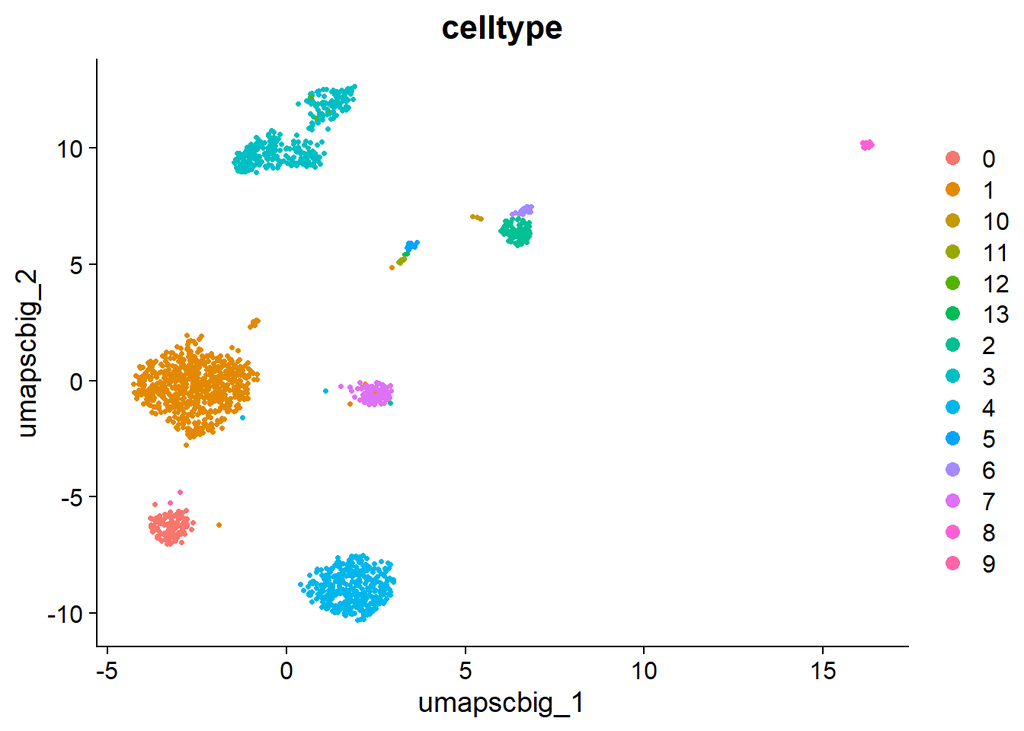

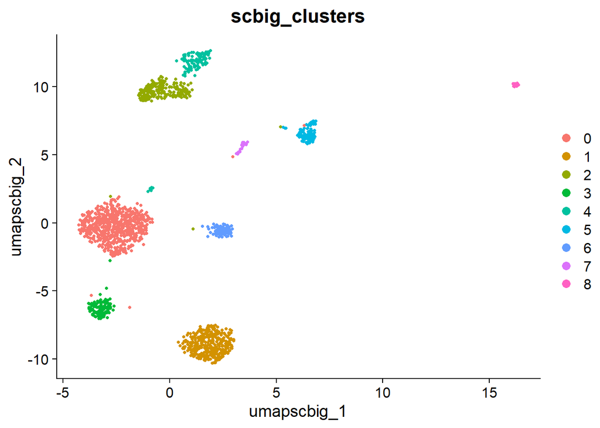

```r
DimPlot(
    data,
    reduction = "umap.scbig",
    group.by = c("celltype", "scbig_clusters"),
    combine = FALSE, label.size = 2
)
```